# Density estimation

Pedro Delicado

07/set./2022

## 1. Histograms

### Certificates of Deposit dataset: CDrate data

Three-month certificate of deposit (CD) rates for 69 Long Island banks and thrifts in August 1989 (Smonoff, 1996). Two types of institutions: banks and thrifts.

Reading CDrate.

```r
cdrate.df <-read.table("cdrate.dat")
head(cdrate.df)
```

```
##     V1 V2
## 1 7.56  0
## 2 7.57  0
## 3 7.71  0
## 4 7.82  0
## 5 7.82  0
## 6 7.90  0
```

```r
CDrate <- cdrate.df[,1]
sort(CDrate)
```

```
##  [1] 7.51 7.56 7.57 7.71 7.75 7.82 7.82 7.90 7.90 8.00 8.00 8.00 8.00 8.00 8.00
## [16] 8.00 8.00 8.00 8.00 8.05 8.05 8.06 8.11 8.15 8.17 8.20 8.25 8.25 8.30 8.30
## [31] 8.30 8.33 8.33 8.33 8.34 8.35 8.35 8.36 8.40 8.40 8.40 8.40 8.40 8.40 8.40
## [46] 8.45 8.49 8.49 8.49 8.50 8.50 8.50 8.50 8.50 8.50 8.50 8.50 8.50 8.50 8.51
## [61] 8.52 8.55 8.57 8.65 8.65 8.70 8.71 8.75 8.78
```

```r
# Stem-and-Leaf plot
stem(CDrate)
```

```
##
##   The decimal point is 1 digit(s) to the left of the |
##
##   74 | 167
##   76 | 15
##   78 | 2200
##   80 | 0000000000556157
##   82 | 0550003334556
##   84 | 0000000599900000000001257
##   86 | 550158
```

The histogram as a function.

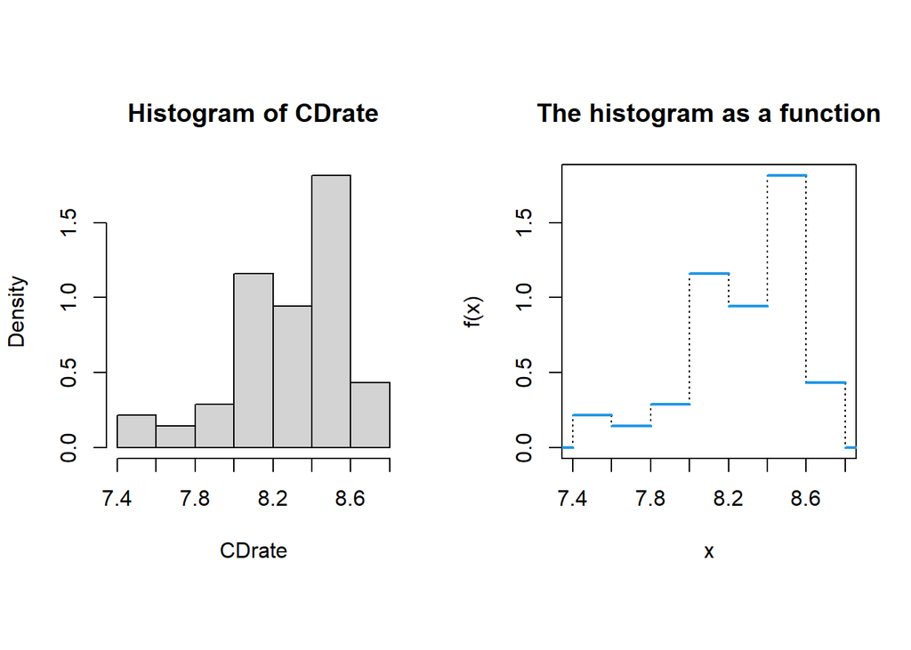

```r
op<-par(mfrow=c(1,2),pty='s')
hcdr <- hist(CDrate,breaks=seq(7.3999,8.7999,by=.2),fre=F)
#hcdr <- hist(CDrate,breaks=seq(7.3999,8.7999,by=.2),plot=FALSE)
plot(stepfun(hcdr$breaks,c(0,hcdr$density,0)),do.points = F,lty=3,
     main="The histogram as a function", xlim=c(7.4,8.8))
plot(stepfun(hcdr$breaks,c(0,hcdr$density,0)),verticals=F,do.points = F,add=T,lwd=2, col=4)
```

```r
par(op)
```

### Data: Boston Housing

We’ll use the `MASS::Boston` dataset, that contains median house values from Boston neighbourhoods.

```r
data("Boston", package = "MASS")
head(Boston)
```

```
##      crim zn indus chas   nox    rm  age    dis rad tax ptratio  black lstat
## 1 0.00632 18  2.31    0 0.538 6.575 65.2 4.0900   1 296    15.3 396.90  4.98
## 2 0.02731  0  7.07    0 0.469 6.421 78.9 4.9671   2 242    17.8 396.90  9.14
## 3 0.02729  0  7.07    0 0.469 7.185 61.1 4.9671   2 242    17.8 392.83  4.03
## 4 0.03237  0  2.18    0 0.458 6.998 45.8 6.0622   3 222    18.7 394.63  2.94
## 5 0.06905  0  2.18    0 0.458 7.147 54.2 6.0622   3 222    18.7 396.90  5.33
## 6 0.02985  0  2.18    0 0.458 6.430 58.7 6.0622   3 222    18.7 394.12  5.21
##   medv
## 1 24.0
## 2 21.6
## 3 34.7
## 4 33.4
## 5 36.2
## 6 28.7
```

The intervals defining a histogram can have different width.

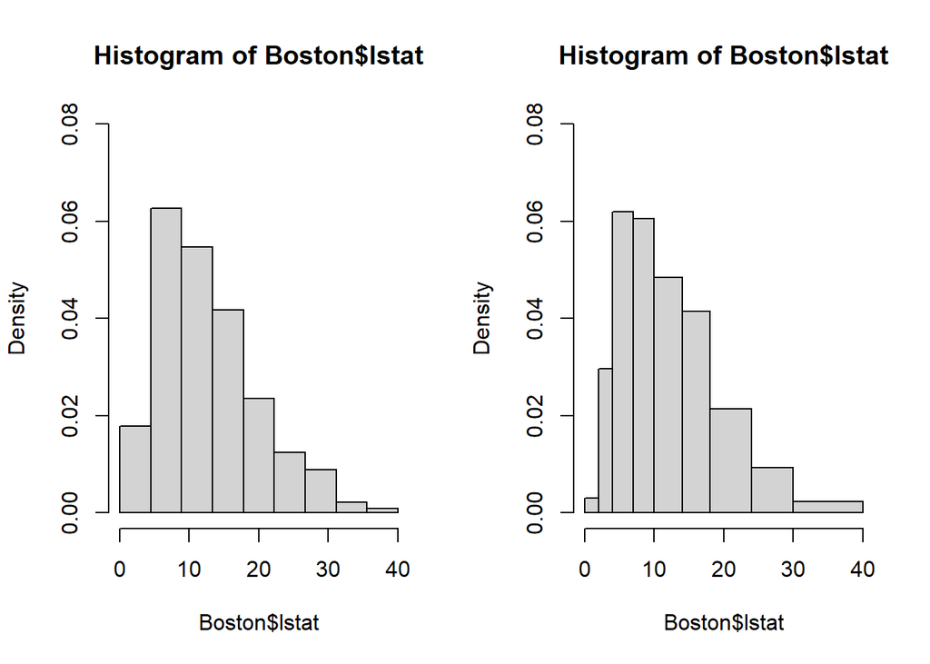

```r
op<-par(mfrow=c(1,2))
nbr=10
hist(Boston$lstat,br=seq(0,40,l=nbr),freq=F,xlim=c(0,40),ylim=c(0,.08))


breaks <- c(0,2,4,7,10,14,18,24,30,40)
hist(Boston$lstat,br=breaks,freq=F,xlim=c(0,40),ylim=c(0,.08))
```

```r
par(op)
```

Effect of the width of the intervals (or equivalently, the number of intervals) in the histogram appearence.

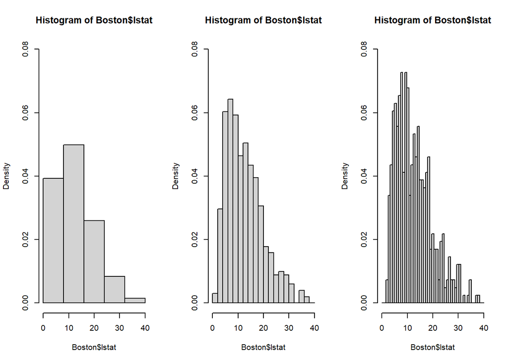

```r
op<-par(mfrow=c(1,3))
nbr=6; hist(Boston$lstat,br=seq(0,40,l=nbr),freq=F,xlim=c(0,40),ylim=c(0,.08))
nbr=21; hist(Boston$lstat,br=seq(0,40,l=nbr),freq=F,xlim=c(0,40),ylim=c(0,.08))
nbr=50; hist(Boston$lstat,br=seq(0,40,l=nbr),freq=F,xlim=c(0,40),ylim=c(0,.08))
```

```r
par(op)
```

### Simulating data from a mixture of `k` normals

Generate data from a density function $f(x)$ that is the mixture of $k$ normals with parameters $(\mu_i,\sigma_i^2)$, $i=1,\ldots,k$, respectively:

$$f(x) = \sum_{i=1}^k \alpha_i f_{N(\mu_i,\sigma_i^2)}(x),$$
where $\alpha_i\ge 0$ and $\sum_{i=1}^k \alpha_i=1$.

```r
# graph.mixt
# Input:
#    k: number mixture components
#    mu: vector of length k with the mean values of the k normals
#    sigma: vector of length k with the st.dev. values of the k normals
#    alpha: vector of length k with the weights of each normal
#    graphic: logical value indicating if the mixture density must be plotted
#    ...: Other parameters passed to plot()
#
# Output:
#    L, U: extremes of the interval where the mixture density is plotted
#    x: points at which the mixture density is evaluated
#    fx: value of the mixture density at x
#
graph.mixt<-
function(k=1, mu=seq(-2*(k-1),2*(k-1),length=k), sigma=seq(1,1,length=k), alpha=seq(1/k,1/k,length=k), graphic=TRUE,...)
{
   L<-min(mu-3*sigma)
   U<-max(mu+3*sigma)

   x<- seq(from=L,to=U,length=200)
   fx<- 0*x
   Salpha<-sum(alpha)
   for(i in 1:k){
    p<-alpha[i]/Salpha
#       fx <- fx + p*exp(-.5*((x-mu[i])/sigma[i])^2)/(sqrt(2*pi)*sigma[i])
    fx <- fx + p*dnorm(x,mu[i],sigma[i])
   }
   if (graphic){
      plot(x,fx,type="l",...)
   }
   return(list(L = L, U = U, x = x, fx = fx))
}

# sim.mixt
# Input:
#    n: number of simulated data
#    k: number mixture components
#    mu: vector of length k with the mean values of the k normals
#    sigma: vector of length k with the st.dev. values of the k normals
#    alpha: vector of length k with the weights of each normal
#    graphic: logical value indicating if the mixture density and the
#              histogram of the simulated data must be plotted
#    ...: Other parameters passed to plot()
#
# Output:
#    x: simulated data
#
# Requires:
#    graph.mixt
sim.mixt <- function(n=1,k=1,
         mu=seq(-2*(k-1),2*(k-1),length=k),
         sigma=seq(1,1,length=k),
         alpha=seq(1/k,1/k,length=k), graphic=FALSE,...)
{
   csa<-cumsum(alpha)
   x<-runif(n)

   for (i in 1:n){
      comp<-sum(csa<=x[i])+1
      x[i]<-rnorm(1,mu[comp],sigma[comp])
   }
   if(graphic) {
      out<-graph.mixt(k, mu, sigma, alpha, gr=FALSE)
      hist(x,freq = FALSE,
           ylim=c(0,max(c(max(out$fx),max(hist(x,plot=FALSE)$density)))))
      lines(out$x,out$fx,lty=1,lwd=2)
   }
   return(x)
}
```

Generate $n=100$ data from

$$f(x) = (3/4)N(x; m = 0, s = 1) +(1/4) N(x; m = 3/2, s = 1/3)$$

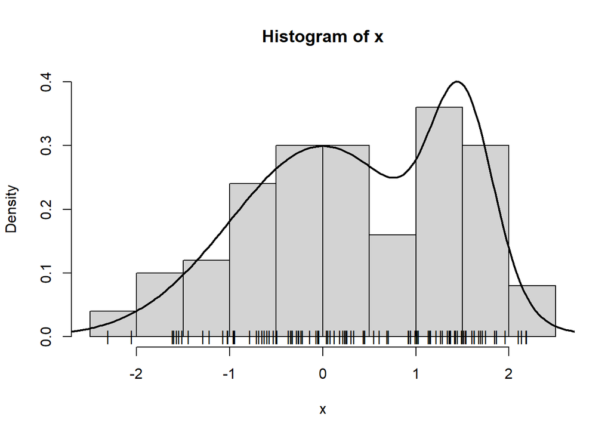

```r
set.seed(123)
n <- 100
mu <- c(0,3/2)
sigma <- c(1,1/3)
alpha <- c(3/4,1/4)
x <- sim.mixt(n=n, k=2, mu=mu, sigma=sigma, alpha=alpha, gr=T)
points(x,0*x,pch="|")
```

### Variablity plots of the histogram density estimator

We have generated $n=100$ data from

$$X\sim f(x) = (3/4)N(x; m = 0, s = 1) +(1/4) N(x; m = 3/2, s = 1/3)$$
In order to plot histograms, one of the ways to compute the appropiate width of boxes is to apply the Scott’s formula that would be optimal (in an asymptotic sense) if the data are normal:
$$b = 3.49 \, \mbox{St.Dev}(X) n^{-1/3}.$$
Let us compute $\mbox{St.Dev}(X)$. The expected value of $X$ is
$$\mathbb{E} (X)=\frac{3}{4} 0 + \frac{1}{4} \frac{3}{2}=\frac{3}{8}.$$
Doing similar computations,
$$\mathbb{E} (X^2)=
\frac{3}{4} 1 +
\frac{1}{4} \left(\frac{1}{9} + \left(\frac{3}{2}\right)^2\right)
=\frac{193}{144},$$
and
$$\mbox{Var}(X)=\frac{193}{144}-\left(\frac{3}{8}\right)^2=
\frac{691}{576}=1.199653,$$
so
$$\mbox{St.Dev}(X)=\sqrt{\mbox{Var}(X)}=1.095287$$

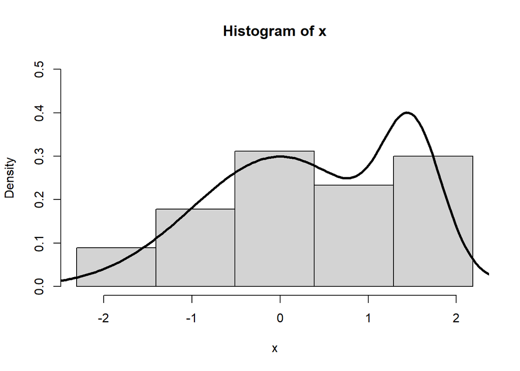

```r
sigma.mixt <- 1.095287
b <- 3.49 * sigma.mixt * length(x)^(-1/3)
# nc: number of boxes
nc <- ceiling(diff(range(x))/b)
boxes <- seq(min(x),max(x),length=nc)
mixt.2 <- graph.mixt(k=2, mu=mu, sigma=sigma, alpha=alpha, lwd=3, graphic = FALSE)
hx <- hist(x, breaks=boxes,freq=F,ylim=c(0,.5))
lines(mixt.2$x, mixt.2$fx, lwd=3)
```

```r
names(hx)
```

```
## [1] "breaks"   "counts"   "density"  "mids"     "xname"    "equidist"
```

Now we repeat the generation of the data $S=30$ times and we plot the resulting histograms at the same graphic.

Moreover we do this exercise for 3 different boxes widths: small ($b/3$), medium ($b$) and large ($3b$).

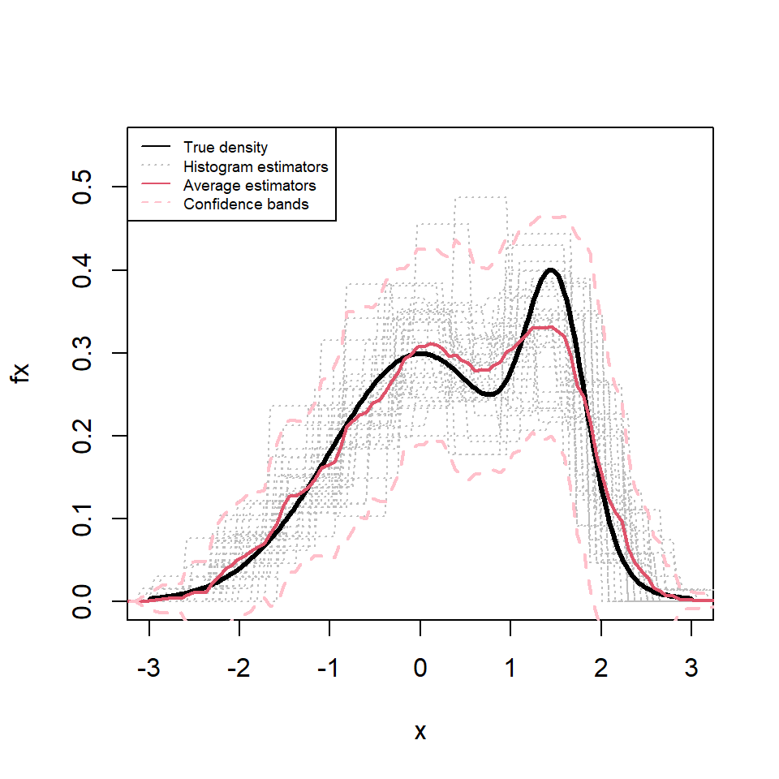

```r
S <- 30
axis.x <- seq(-3.5,3.5,length=100)
S.hists <- matrix(0,nrow = length(axis.x),ncol=S)
n <- 100
mixt.2 <- graph.mixt(k=2, mu=mu, sigma=sigma, alpha=alpha, lwd=3, ylim=c(0,.55))
sigma.mixt <- 1.095287
b <- 3.49 * sigma.mixt * n^(-1/3)
for (i in seq(1,S)){
   x <- sim.mixt(n=n, k=2, mu=mu, sigma=sigma, alpha=alpha, gr=F)
   nc <- ceiling(diff(range(x))/b)
   boxes <- seq(min(x),max(x),length=nc+2)
#   hist(x, breaks=cajas,freq=F, add=TRUE,lty=3)
   tmp <- hist(x, breaks=boxes, plot=FALSE)
   box.axis.x <- findInterval(axis.x,boxes)+1
   fH <- c(0,tmp$density,0)
   S.hists[,i]<-fH[box.axis.x]
   lines(axis.x,S.hists[,i],lty=3,col="grey")
}
lines(mixt.2$x, mixt.2$fx, lwd=3)
m.S.hists <- apply(S.hists,1,mean)
sd.S.hists <- apply(S.hists,1,sd)
lines(axis.x,m.S.hists,col=2,lwd=2)
lines(axis.x,m.S.hists+2*sd.S.hists,col="pink",lwd=2,lty=2)
lines(axis.x,m.S.hists-2*sd.S.hists,col="pink",lwd=2,lty=2)
legend("topleft",
       c("True density","Histogram estimators",
         "Average estimators","Confidence bands"),
       lty=c(1,3,1,2),
       col=c(1,"grey",2,"pink"),cex=.6)
```

Now we do this exercise for 3 different boxes widths: small ($b/3$), medium ($b$) and large ($3b$).

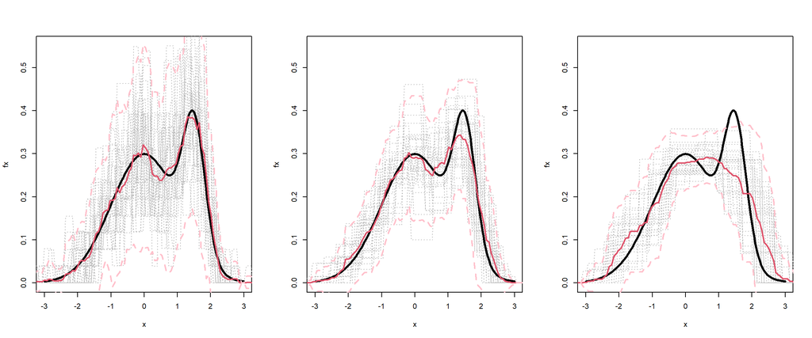

```r
S <- 30
axis.x <- seq(-3.5,3.5,length=100)
n <- 100
sigma.mixt <- 1.095287
op <- par(mfrow=c(1,3))
# small
mixt.2 <- graph.mixt(k=2, mu=mu, sigma=sigma, alpha=alpha,
                     lwd=3,ylim=c(0,.55))
b <- (3.49 * sigma.mixt * n^(-1/3))/3
S.hists <- matrix(0,nrow = length(axis.x),ncol=S)
for (i in seq(1,S)){
   x <- sim.mixt(n=n, k=2, mu=mu, sigma=sigma, alpha=alpha, gr=F)
   nc <- ceiling(diff(range(x))/b)
   boxes <- seq(min(x),max(x),length=nc+2)
#   hist(x, breaks=cajas,freq=F, add=TRUE,lty=3)
   tmp <- hist(x, breaks=boxes, plot=FALSE)
   box.axis.x <- findInterval(axis.x,boxes)+1
   fH <- c(0,tmp$density,0)
   S.hists[,i]<-fH[box.axis.x]
   lines(axis.x,S.hists[,i],lty=3,col="grey")
}
lines(mixt.2$x, mixt.2$fx, lwd=3)
m.S.hists <- apply(S.hists,1,mean)
sd.S.hists <- apply(S.hists,1,sd)
lines(axis.x,m.S.hists,col=2,lwd=2)
lines(axis.x,m.S.hists+2*sd.S.hists,col="pink",lwd=2,lty=2)
lines(axis.x,m.S.hists-2*sd.S.hists,col="pink",lwd=2,lty=2)

# medium
mixt.2 <- graph.mixt(k=2, mu=mu, sigma=sigma, alpha=alpha,
                     lwd=3,ylim=c(0,.55))
b <- 3.49 * sigma.mixt * n^(-1/3)
S.hists <- matrix(0,nrow = length(axis.x),ncol=S)
for (i in seq(1,S)){
   x <- sim.mixt(n=n, k=2, mu=mu, sigma=sigma, alpha=alpha, gr=F)
   nc <- ceiling(diff(range(x))/b)
   boxes <- seq(min(x),max(x),length=nc+2)
#   hist(x, breaks=cajas,freq=F, add=TRUE,lty=3)
   tmp <- hist(x, breaks=boxes, plot=FALSE)
   box.axis.x <- findInterval(axis.x,boxes)+1
   fH <- c(0,tmp$density,0)
   S.hists[,i]<-fH[box.axis.x]
   lines(axis.x,S.hists[,i],lty=3,col="grey")
}
lines(mixt.2$x, mixt.2$fx, lwd=3)
m.S.hists <- apply(S.hists,1,mean)
sd.S.hists <- apply(S.hists,1,sd)
lines(axis.x,m.S.hists,col=2,lwd=2)
lines(axis.x,m.S.hists+2*sd.S.hists,col="pink",lwd=2,lty=2)
lines(axis.x,m.S.hists-2*sd.S.hists,col="pink",lwd=2,lty=2)

# small
mixt.2 <- graph.mixt(k=2, mu=mu, sigma=sigma, alpha=alpha,
                     lwd=3,ylim=c(0,.55))
b <- (3.49 * sigma.mixt * n^(-1/3))*3
for (i in seq(1,S)){
   x <- sim.mixt(n=n, k=2, mu=mu, sigma=sigma, alpha=alpha, gr=F)
   nc <- ceiling(diff(range(x))/b)
   boxes <- seq(min(x),max(x),length=nc+2)
#   hist(x, breaks=cajas,freq=F, add=TRUE,lty=3)
   tmp <- hist(x, breaks=boxes, plot=FALSE)
   box.axis.x <- findInterval(axis.x,boxes)+1
   fH <- c(0,tmp$density,0)
   S.hists[,i]<-fH[box.axis.x]
   lines(axis.x,S.hists[,i],lty=3,col="grey")
}
lines(mixt.2$x, mixt.2$fx, lwd=3)
m.S.hists <- apply(S.hists,1,mean)
sd.S.hists <- apply(S.hists,1,sd)
lines(axis.x,m.S.hists,col=2,lwd=2)
lines(axis.x,m.S.hists+2*sd.S.hists,col="pink",lwd=2,lty=2)
lines(axis.x,m.S.hists-2*sd.S.hists,col="pink",lwd=2,lty=2)
```

```r
par(op)
```

## 2. Kernel density estimation

### Density estimation by a moving histogram

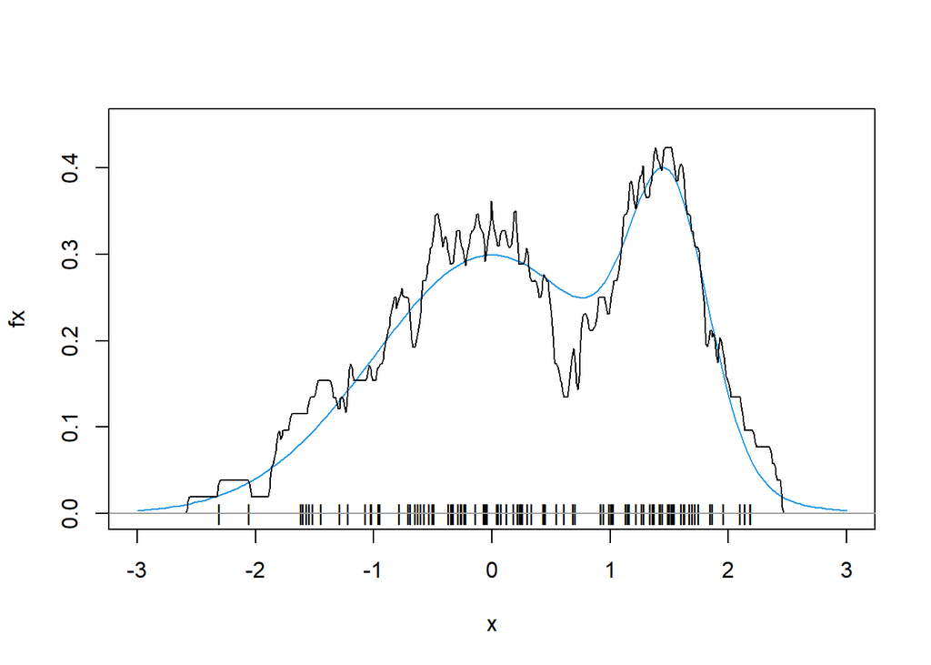

```r
set.seed(123)
n <- 100
mu <- c(0,3/2)
sigma <- c(1,1/3)
alpha <- c(3/4,1/4)

out <- graph.mixt(k=2, mu=mu, sigma=sigma, alpha=alpha, col=4,ylim=c(0,.45))
x <- sim.mixt(n=n, k=2, mu=mu, sigma=sigma, alpha=alpha, gr=F)

h <- 0.3/2
lines( density(x, bw = h, kernel = "rectangular") )
points(x,0*x,pch="|")
abline(h=0,col=8)
```

### Kernel density estimation: moving and smoothing the histogram

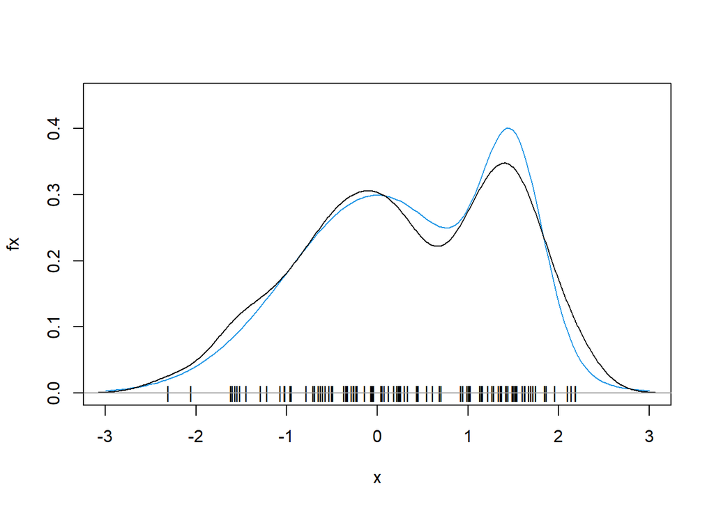

```r
set.seed(123)
n <- 100
mu <- c(0,3/2)
sigma <- c(1,1/3)
alpha <- c(3/4,1/4)

out <- graph.mixt(k=2, mu=mu, sigma=sigma, alpha=alpha, col=4,ylim=c(0,.45))
x <- sim.mixt(n=n, k=2, mu=mu, sigma=sigma, alpha=alpha, gr=F)

h <- 0.3
lines( density(x, bw = h, kernel = "gaussian") )
points(x,0*x,pch="|")
abline(h=0,col=8)
```

### Variablility plot for the kernel density estimator

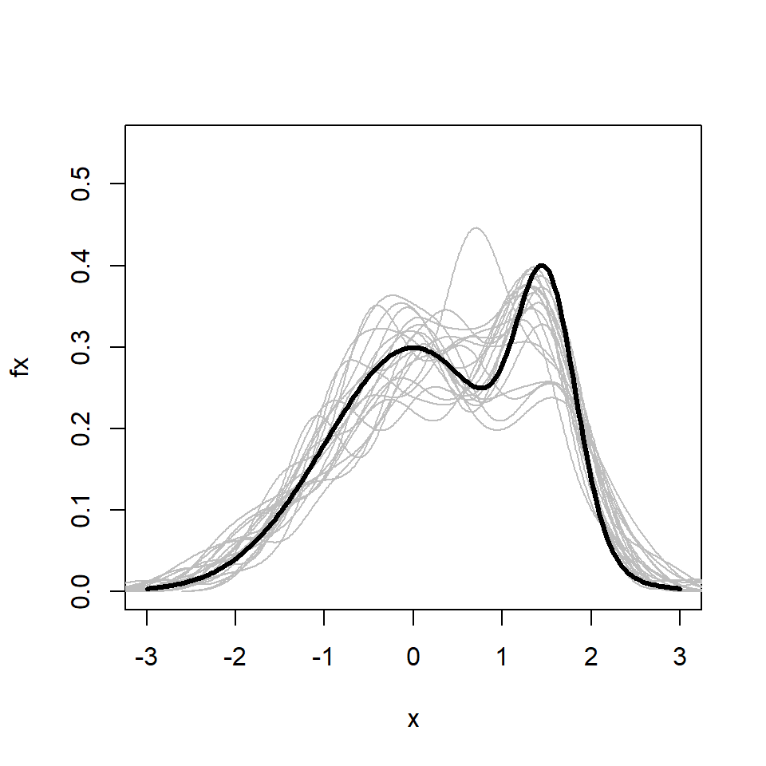

```r
S <- 20
n <- 100
mu <- c(0,3/2)
sigma <- c(1,1/3)
alpha <- c(3/4,1/4)
mixt.2 <- graph.mixt(k=2, mu=mu, sigma=sigma, alpha=alpha, lwd=3,ylim=c(0,0.55))
for (i in seq(1,S)){
   x <- sim.mixt(n=n, k=2, mu=mu, sigma=sigma, alpha=alpha, gr=F)
   lines(density(x,adjust=.75),col="grey")
}
lines(mixt.2$x, mixt.2$fx, lwd=3)
```

```r
# Defining the function variability_plot_kernel
#
variability_plot_kerenl <- function(k=1,
         mu=seq(-2*(k-1),2*(k-1),length=k),
         sigma=seq(1,1,length=k),
         alpha=seq(1/k,1/k,length=k),
         S=20, n=100, r=100,
         h="nrd0", ...){
   # computing the density of thr mixture of normals
   k <- length(mu)

   minx <- min(mu-3*sigma)
   maxx <- max(mu+3*sigma)
   y <- seq(minx,maxx,length=r)
   fy <- 0*y
   Salpha<-sum(alpha)
   for(i in 1:k){
    p<-alpha[i]/Salpha
   #    fy <- fy + p*exp(-.5*((y-mu[i])/sigma[i])^2)/(sqrt(2*pi)*sigma[i])
    fy <- fy + p*dnorm(y,mu[i],sigma[i])
   }

   hfy <- matrix(0,S,r)

   for (i in 1:S){
      x <- sim.mixt(n=n,k=k,mu=mu,sigma=sigma,alpha=alpha)
      dx <- density(x, bw=h, from=minx, to=maxx, n=r, ...)
      hfy[i,] <- dx$y
   }


   m_hf <- apply(hfy,2,mean)
   sd_hf <- apply(hfy,2,sd)

   delta <- y[2]-y[1]
   ECM <- sd_hf^2+(fy-m_hf)^2
   MISE <- sum(ECM)*delta
   #[MISE,naux] <- simpson(ECM,minx,maxx)

   plot(y,fy,ty="l",  lwd=3, ...)
   title(main=paste("MISE= ",MISE,sep=""))
   lines(y,m_hf,col=2)
   L <- m_hf-1.96*sd_hf
   U <- m_hf+1.96*sd_hf
   lines(y,L,col=3,lty=2)
   lines(y,U,col=3,lty=2)

   return(list(y=y,fy=fy,m_hf=m_hf,sd_hf=sd_hf,MISE=MISE))
}
```

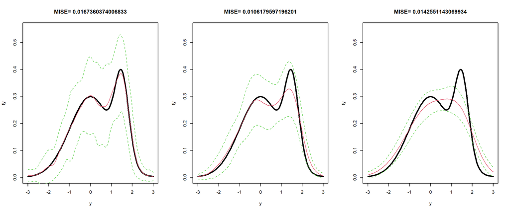

```r
S <- 30
n <- 100
mu <- c(0,3/2)
sigma <- c(1,1/3)
alpha <- c(3/4,1/4)

r <- 100

op<-par(mfrow=c(1,3))
vpk.1 <- variability_plot_kerenl(mu=mu, sigma=sigma, alpha=alpha,
         S=S, n=n, r=r, h="nrd0", adjust=.4,ylim=c(0,0.55))

vpk.2 <- variability_plot_kerenl(mu=mu, sigma=sigma, alpha=alpha,
         S=S, n=n, r=r, h="nrd0", adjust=.75,ylim=c(0,0.55))

vpk.3 <- variability_plot_kerenl(mu=mu, sigma=sigma, alpha=alpha,
         S=S, n=n, r=r, h="nrd0", adjust=1.5,ylim=c(0,0.55))
```

```r
par(op)
```

## 3. Bivariate density estimation.

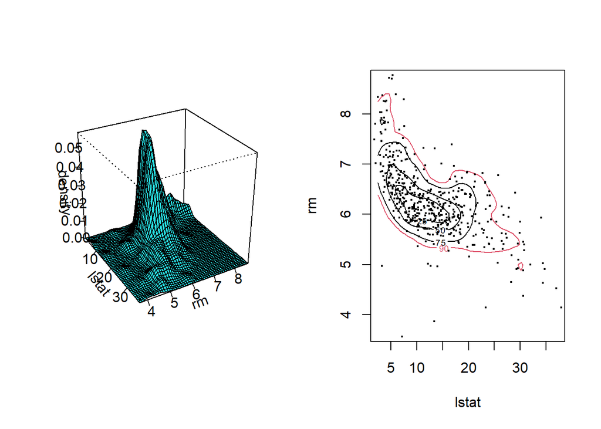

```r
library(sm)
op <- par(mfrow=c(1,2))
sm.density(cbind(Boston$lstat,Boston$rm),h=c(1.5,.15),phi=30,theta=60,col=5,
           xlab="lstat",ylab="rm",zlab="density")

sm.density(cbind(Boston$lstat,Boston$rm),h=c(1.5,.15),display="slice",
           xlab="lstat",ylab="rm")
sm.density(cbind(Boston$lstat,Boston$rm),h=c(1.5,.15),display="slice",add=T,col=2,props=c(90))
points(Boston$lstat,Boston$rm,pch=19,cex=.3)
```

```r
par(op)
```

```r
library(rgl)
plot(Boston$lstat,Boston$rm)
out <- sm.density(cbind(Boston$lstat,Boston$rm),
                  h=c(1.5,.15),display="none")
persp3d(x=out$eval.points[,1],
        y=out$eval.points[,2],
        z=out$estimate,col="lightblue")
```